# Working on Mileage per gallon performances of various cars-Auto-mpg dataset

Abdlmutaleb Boshanna

2023-08-13

## In this project, I will work with a widely used dataset in statistics, economics, and machine learning known as the Auto-MPG dataset.

## 1.2. Download the data:

I am going to use read.table to import the data into r.

```r
autompg = read.table("http://archive.ics.uci.edu/ml/machine-learning-databases/auto-mpg/auto-mpg.data",
quote = "\"", comment.char = "", stringsAsFactors = FALSE)
str (autompg)
```

```
## 'data.frame':    398 obs. of  9 variables:
##  $ V1: num  18 15 18 16 17 15 14 14 14 15 ...
##  $ V2: int  8 8 8 8 8 8 8 8 8 8 ...
##  $ V3: num  307 350 318 304 302 429 454 440 455 390 ...
##  $ V4: chr  "130.0" "165.0" "150.0" "150.0" ...
##  $ V5: num  3504 3693 3436 3433 3449 ...
##  $ V6: num  12 11.5 11 12 10.5 10 9 8.5 10 8.5 ...
##  $ V7: int  70 70 70 70 70 70 70 70 70 70 ...
##  $ V8: int  1 1 1 1 1 1 1 1 1 1 ...
##  $ V9: chr  "chevrolet chevelle malibu" "buick skylark 320" "plymouth satellite" "amc rebel sst" ...
```

```r
class(autompg)
```

```
## [1] "data.frame"
```

```r
dim(autompg)
```

```
## [1] 398   9
```

```r
colnames(autompg)
```

```
## [1] "V1" "V2" "V3" "V4" "V5" "V6" "V7" "V8" "V9"
```

## 1.3. Go to the website and change the column names with the correct ones.

```r
colnames(autompg) <- c("mpg", "cylinders", "displacement", "horsepower", "weight", "acceleration", "modelyear", "origin", "carname")
colnames(autompg)
```

```
## [1] "mpg"          "cylinders"    "displacement" "horsepower"   "weight"
## [6] "acceleration" "modelyear"    "origin"       "carname"
```

I’d like the keep the main data, and open a new file for the data I am goint to work on. I called it (autompg1) ##

```r
autompg1 <- as.data.frame(autompg)
head(autompg1)
```

```
##   mpg cylinders displacement horsepower weight acceleration modelyear origin
## 1  18         8          307      130.0   3504         12.0        70      1
## 2  15         8          350      165.0   3693         11.5        70      1
## 3  18         8          318      150.0   3436         11.0        70      1
## 4  16         8          304      150.0   3433         12.0        70      1
## 5  17         8          302      140.0   3449         10.5        70      1
## 6  15         8          429      198.0   4341         10.0        70      1
##                     carname
## 1 chevrolet chevelle malibu
## 2         buick skylark 320
## 3        plymouth satellite
## 4             amc rebel sst
## 5               ford torino
## 6          ford galaxie 500
```

```r
colnames(autompg1)
```

```
## [1] "mpg"          "cylinders"    "displacement" "horsepower"   "weight"
## [6] "acceleration" "modelyear"    "origin"       "carname"
```

## 1.4. Check the data and correct the class (Factor, Int, Num, etc.) of each column to an appropiate one, if necessary.

```r
str(autompg1)
```

```
## 'data.frame':    398 obs. of  9 variables:
##  $ mpg         : num  18 15 18 16 17 15 14 14 14 15 ...
##  $ cylinders   : int  8 8 8 8 8 8 8 8 8 8 ...
##  $ displacement: num  307 350 318 304 302 429 454 440 455 390 ...
##  $ horsepower  : chr  "130.0" "165.0" "150.0" "150.0" ...
##  $ weight      : num  3504 3693 3436 3433 3449 ...
##  $ acceleration: num  12 11.5 11 12 10.5 10 9 8.5 10 8.5 ...
##  $ modelyear   : int  70 70 70 70 70 70 70 70 70 70 ...
##  $ origin      : int  1 1 1 1 1 1 1 1 1 1 ...
##  $ carname     : chr  "chevrolet chevelle malibu" "buick skylark 320" "plymouth satellite" "amc rebel sst" ...
```

```r
library(magrittr)
```

Convert character varaibles in the model to factor variables,

```r
autompg1 <- as.data.frame(autompg)
colms <- sapply(autompg1, is.character)
autompg1[colms] <- lapply(autompg[colms], as.factor)
```

Convert horsepower from factor to numeric.

```r
autompg1$horsepower=as.numeric(levels(autompg1$horsepower))[autompg1$horsepower]
```

I also converted origin from interger to factor (dummy variable from 1 to 3). 1 represnts USA 2 represnts Eurpoe 3 represnts Janpan

```r
origins <- c('USA', 'Europe', 'Japan')
autompg1$origin <- factor(autompg1$origin, labels = origins)
str(autompg1)
```

```
## 'data.frame':    398 obs. of  9 variables:
##  $ mpg         : num  18 15 18 16 17 15 14 14 14 15 ...
##  $ cylinders   : int  8 8 8 8 8 8 8 8 8 8 ...
##  $ displacement: num  307 350 318 304 302 429 454 440 455 390 ...
##  $ horsepower  : num  130 165 150 150 140 198 220 215 225 190 ...
##  $ weight      : num  3504 3693 3436 3433 3449 ...
##  $ acceleration: num  12 11.5 11 12 10.5 10 9 8.5 10 8.5 ...
##  $ modelyear   : int  70 70 70 70 70 70 70 70 70 70 ...
##  $ origin      : Factor w/ 3 levels "USA","Europe",..: 1 1 1 1 1 1 1 1 1 1 ...
##  $ carname     : Factor w/ 305 levels "amc ambassador brougham",..: 50 37 232 15 162 142 55 224 242 2 ...
```

## 1.5. How many missing values do we have in the data?

```r
any(is.na(autompg1))
```

```
## [1] TRUE
```

```r
sum(is.na(autompg1))
```

```
## [1] 6
```

The number of missing values is 6.

Alternative way to find missing values:

```r
which(autompg$horsepower == "?")
```

```
## [1]  33 127 331 337 355 375
```

```r
dim(autompg1)
```

```
## [1] 398   9
```

```r
subset_horsepower <- subset(autompg1, autompg1$horsepower != "?")
dim(subset_horsepower)
```

```
## [1] 392   9
```

The number of observations of the main data (autompg1) was 398. after droping every observation that includes “?” values, the number of observations becomes 392 (rows). Therefore, the number of missing values (?) is 398 -392 = 6.

I also can run this

```r
sum(!complete.cases(autompg1))
```

```
## [1] 6
```

## 1.6. Identify the number of NA’s in each column.

```r
colSums(is.na(autompg1)|autompg1 == 'na')
```

```
##          mpg    cylinders displacement   horsepower       weight acceleration
##            0            0            0            6            0            0
##    modelyear       origin      carname
##            0            0            0
```

```r
## OR
colSums(is.na(autompg1)|autompg1 == '?')
```

```
##          mpg    cylinders displacement   horsepower       weight acceleration
##            0            0            0            6            0            0
##    modelyear       origin      carname
##            0            0            0
```

I count the number of na, blank, and “?” using the above code. I created the same table.

horsepower shows 6 missing values.

## 1.7. What’s the mean of hp in our data? If you are not able to get a number, why? How would you solve this problem? Hint: na.rm

```r
mean(autompg1$horsepower)
```

```
## [1] NA
```

```r
# I try to visualize the data
autompg1$horsepower
```

```
##   [1] 130 165 150 150 140 198 220 215 225 190 170 160 150 225  95  95  97  85
##  [19]  88  46  87  90  95 113  90 215 200 210 193  88  90  95  NA 100 105 100
##  [37]  88 100 165 175 153 150 180 170 175 110  72 100  88  86  90  70  76  65
##  [55]  69  60  70  95  80  54  90  86 165 175 150 153 150 208 155 160 190  97
##  [73] 150 130 140 150 112  76  87  69  86  92  97  80  88 175 150 145 137 150
##  [91] 198 150 158 150 215 225 175 105 100 100  88  95  46 150 167 170 180 100
## [109]  88  72  94  90  85 107  90 145 230  49  75  91 112 150 110 122 180  95
## [127]  NA 100 100  67  80  65  75 100 110 105 140 150 150 140 150  83  67  78
## [145]  52  61  75  75  75  97  93  67  95 105  72  72 170 145 150 148 110 105
## [163] 110  95 110 110 129  75  83 100  78  96  71  97  97  70  90  95  88  98
## [181] 115  53  86  81  92  79  83 140 150 120 152 100 105  81  90  52  60  70
## [199]  53 100  78 110  95  71  70  75  72 102 150  88 108 120 180 145 130 150
## [217]  68  80  58  96  70 145 110 145 130 110 105 100  98 180 170 190 149  78
## [235]  88  75  89  63  83  67  78  97 110 110  48  66  52  70  60 110 140 139
## [253] 105  95  85  88 100  90 105  85 110 120 145 165 139 140  68  95  97  75
## [271]  95 105  85  97 103 125 115 133  71  68 115  85  88  90 110 130 129 138
## [289] 135 155 142 125 150  71  65  80  80  77 125  71  90  70  70  65  69  90
## [307] 115 115  90  76  60  70  65  90  88  90  90  78  90  75  92  75  65 105
## [325]  65  48  48  67  67  67  NA  67  62 132 100  88  NA  72  84  84  92 110
## [343]  84  58  64  60  67  65  62  68  63  65  65  74  NA  75  75 100  74  80
## [361]  76 116 120 110 105  88  85  88  88  88  85  84  90  92  NA  74  68  68
## [379]  63  70  88  75  70  67  67  67 110  85  92 112  96  84  90  86  52  84
## [397]  79  82
```

```r
## I also could use this to find ununique data
unique(autompg1$horsepower)
```

```
##  [1] 130 165 150 140 198 220 215 225 190 170 160  95  97  85  88  46  87  90 113
## [20] 200 210 193  NA 100 105 175 153 180 110  72  86  70  76  65  69  60  80  54
## [39] 208 155 112  92 145 137 158 167  94 107 230  49  75  91 122  67  83  78  52
## [58]  61  93 148 129  96  71  98 115  53  81  79 120 152 102 108  68  58 149  89
## [77]  63  48  66 139 103 125 133 138 135 142  77  62 132  84  64  74 116  82
```

R was not able to provide the mean of hourspower becuase this columne comprises missing values (NA).

To handle the missing values, I used “na.rm” which will remove missing values while calculating the mean. The idea here is that if I calculate the mean with missing values, I will not be able to find the mean. The mean = sum of a collection of numbers divided by the count of numbers in in the collection. if one of the number (value) is missing which in R is like “na”, then you’ll not be able to find the mean.

```r
mean(autompg1$horsepower, na.rm = TRUE)
```

```
## [1] 104.4694
```

create a new data without any missing values.

```r
mydata.remove <- na.omit(autompg1)
str(mydata.remove)
```

```
## 'data.frame':    392 obs. of  9 variables:
##  $ mpg         : num  18 15 18 16 17 15 14 14 14 15 ...
##  $ cylinders   : int  8 8 8 8 8 8 8 8 8 8 ...
##  $ displacement: num  307 350 318 304 302 429 454 440 455 390 ...
##  $ horsepower  : num  130 165 150 150 140 198 220 215 225 190 ...
##  $ weight      : num  3504 3693 3436 3433 3449 ...
##  $ acceleration: num  12 11.5 11 12 10.5 10 9 8.5 10 8.5 ...
##  $ modelyear   : int  70 70 70 70 70 70 70 70 70 70 ...
##  $ origin      : Factor w/ 3 levels "USA","Europe",..: 1 1 1 1 1 1 1 1 1 1 ...
##  $ carname     : Factor w/ 305 levels "amc ambassador brougham",..: 50 37 232 15 162 142 55 224 242 2 ...
##  - attr(*, "na.action")= 'omit' Named int [1:6] 33 127 331 337 355 375
##   ..- attr(*, "names")= chr [1:6] "33" "127" "331" "337" ...
```

## 1.8. What are the row and column index numbers for those NA’s in your data. Call that matrix ind.

I created a matrix called “ind”

```r
ind <- matrix(which(autompg$horsepower == "?"), )
ind
```

```
##      [,1]
## [1,]   33
## [2,]  127
## [3,]  331
## [4,]  337
## [5,]  355
## [6,]  375
```

```r
## It did find the rows but it could not find the column. Therefore, I tried a differnt code.


ind <- which(is.na(autompg1), arr.ind=TRUE)
ind
```

```
##      row col
## [1,]  33   4
## [2,] 127   4
## [3,] 331   4
## [4,] 337   4
## [5,] 355   4
## [6,] 375   4
```

```r
# It works fine!
```

## 1.9.A. Replace these NA’s with the average for the corresponding origin.

I tired this code but it did not work

```r
ms <- aggregate(autompg1$horsepower, by=list(autompg1$origin), FUN = mean, na.rm = TRUE)
ms
```

```
##   Group.1         x
## 1     USA 119.04898
## 2  Europe  80.55882
## 3   Japan  79.83544
```

## 1.9.C. Suppose that hp has 133 NA’s. What would you do to eliminate NA’s (No script is needed. Explain your strategy).

The data has 392 observations. when horsepower has 133 NA’s, it would effect my model my decreasing the number of observations. Whenever I included horsepower in my model, I will lose 133 observations. my number of observations if I include horsepower would be 259. I think I will drop horsepower variable from my data in order to have a good number of observations. However, with that being said, if horsepower is my main predictor (IV), I would keep it and run the analysis.

## 2-1. Plot mpg vs. hp, mpg vs. disp, mpg vs. acc. Put these three graphs next to each other. Use titles and different colors in each. Change the axis labels as well. Hint look at par() and mfcol(). Make sure that lables are not too large, otherwise adjust them?

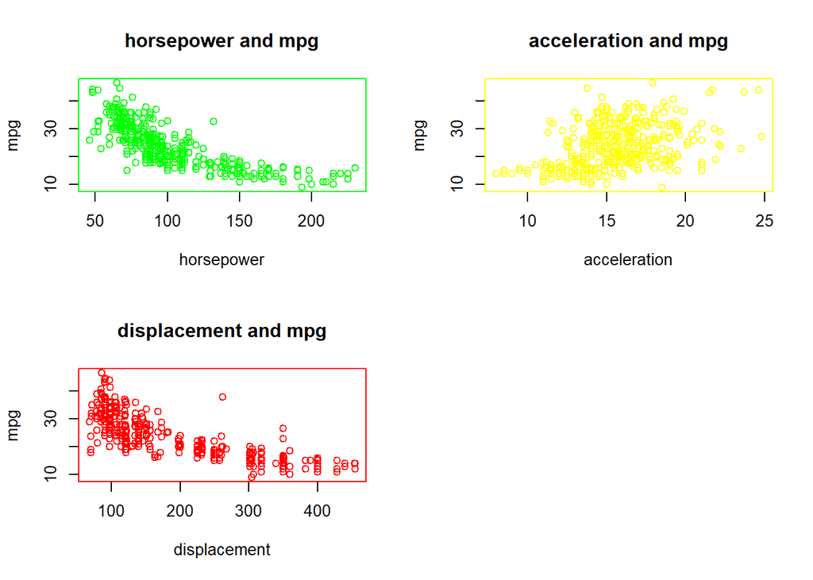

```r
par(mfcol = c(2,2))
par(col= "green")
plot(mydata.remove$horsepower, mydata.remove$mpg, xlab="horsepower", ylab="mpg", main="horsepower and mpg")

par(col= "red")
plot(mydata.remove$displacement, mydata.remove$mpg, xlab="displacement", ylab="mpg", main="displacement and mpg")

par(col= "yellow")
plot(mydata.remove$acceleration, mydata.remove$mpg, xlab="acceleration", ylab="mpg", main="acceleration and mpg")
```

## 2.2. Now have 6 plots (3 variables vs any other 3) with one plot.

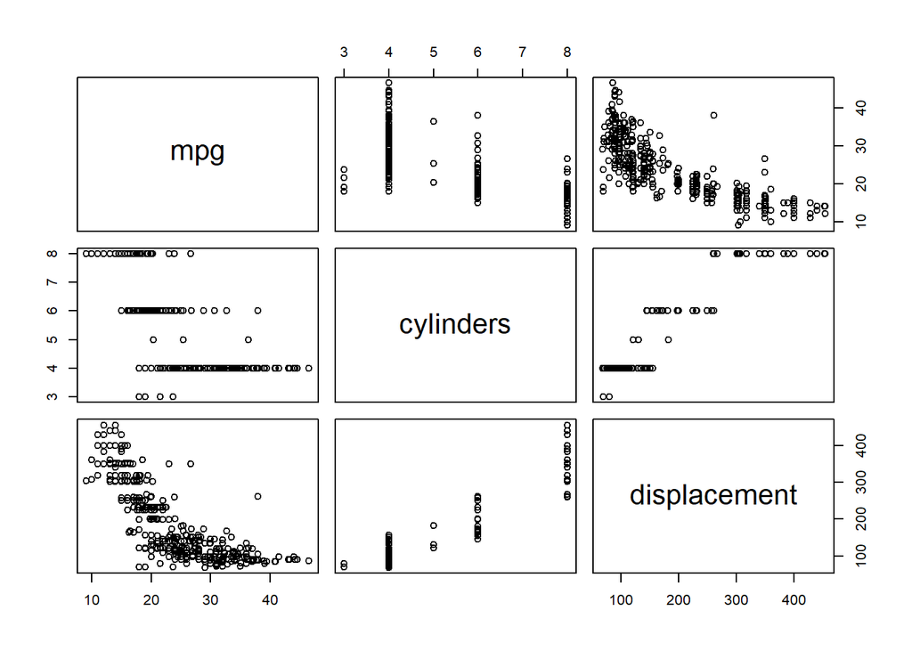

```r
plot(autompg1[,c(1,2,3)])
```

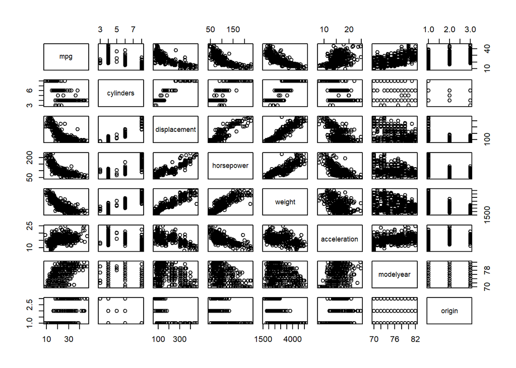

```r
## I also tired this code which gives us a good understanding of the relationship among the predictors (IV variables).

pairs(~mpg + cylinders + displacement + horsepower + weight + acceleration + modelyear + origin, data = mydata.remove)
```

## 2.3. Find the variance-covariance matrix and the correlation matrix of all variables

First, I am going to find correlation matrix.

```r
str(mydata.remove)
```

```
## 'data.frame':    392 obs. of  9 variables:
##  $ mpg         : num  18 15 18 16 17 15 14 14 14 15 ...
##  $ cylinders   : int  8 8 8 8 8 8 8 8 8 8 ...
##  $ displacement: num  307 350 318 304 302 429 454 440 455 390 ...
##  $ horsepower  : num  130 165 150 150 140 198 220 215 225 190 ...
##  $ weight      : num  3504 3693 3436 3433 3449 ...
##  $ acceleration: num  12 11.5 11 12 10.5 10 9 8.5 10 8.5 ...
##  $ modelyear   : int  70 70 70 70 70 70 70 70 70 70 ...
##  $ origin      : Factor w/ 3 levels "USA","Europe",..: 1 1 1 1 1 1 1 1 1 1 ...
##  $ carname     : Factor w/ 305 levels "amc ambassador brougham",..: 50 37 232 15 162 142 55 224 242 2 ...
##  - attr(*, "na.action")= 'omit' Named int [1:6] 33 127 331 337 355 375
##   ..- attr(*, "names")= chr [1:6] "33" "127" "331" "337" ...
```

```r
corr <- cor(mydata.remove[, 1:7])
corr
```

```
##                     mpg  cylinders displacement horsepower     weight
## mpg           1.0000000 -0.7776175   -0.8051269 -0.7784268 -0.8322442
## cylinders    -0.7776175  1.0000000    0.9508233  0.8429834  0.8975273
## displacement -0.8051269  0.9508233    1.0000000  0.8972570  0.9329944
## horsepower   -0.7784268  0.8429834    0.8972570  1.0000000  0.8645377
## weight       -0.8322442  0.8975273    0.9329944  0.8645377  1.0000000
## acceleration  0.4233285 -0.5046834   -0.5438005 -0.6891955 -0.4168392
## modelyear     0.5805410 -0.3456474   -0.3698552 -0.4163615 -0.3091199
##              acceleration  modelyear
## mpg             0.4233285  0.5805410
## cylinders      -0.5046834 -0.3456474
## displacement   -0.5438005 -0.3698552
## horsepower     -0.6891955 -0.4163615
## weight         -0.4168392 -0.3091199
## acceleration    1.0000000  0.2903161
## modelyear       0.2903161  1.0000000
```

There is a negative correlation between mpg (label) Or response variable and the following predictors or independent variables: cylinders, displacement, horsepower, weight.

Also, there is a positive association between mpg and (acceleration and modelyear).

it works. In Stata, we should be able to find the correlatin matrix including dummy vaiables. I am just wondering if I have misunderstood it.

Second, I am going to find variance-covariance matrix.

range.names <- c(“cylinders”, “displacement”, “horsepower”, “weight”, “acceleration”, “modelyear”) names(mydata.remove) <- range.names covmatrix <- matrix(c(cov(mydata.remove)), nrow = 6, ncol = 6)

I tried it many times but it did not work.

## 3.1. Assign your estimations to model1. Find predicted values using model1 you estimated. Calculate MSE and assign it to mse1.

```r
df <- mydata.remove[complete.cases(mydata.remove), ]
model1 <- lm(mpg ~ cylinders + displacement + horsepower + weight + acceleration + modelyear + origin, data = mydata.remove)
summary(model1)
```

```
##
## Call:
## lm(formula = mpg ~ cylinders + displacement + horsepower + weight +
##     acceleration + modelyear + origin, data = mydata.remove)
##
## Residuals:
##     Min      1Q  Median      3Q     Max
## -9.0095 -2.0785 -0.0982  1.9856 13.3608
##
## Coefficients:
##                Estimate Std. Error t value Pr(>|t|)
## (Intercept)  -1.795e+01  4.677e+00  -3.839 0.000145 ***
## cylinders    -4.897e-01  3.212e-01  -1.524 0.128215
## displacement  2.398e-02  7.653e-03   3.133 0.001863 **
## horsepower   -1.818e-02  1.371e-02  -1.326 0.185488
## weight       -6.710e-03  6.551e-04 -10.243  < 2e-16 ***
## acceleration  7.910e-02  9.822e-02   0.805 0.421101
## modelyear     7.770e-01  5.178e-02  15.005  < 2e-16 ***
## originEurope  2.630e+00  5.664e-01   4.643 4.72e-06 ***
## originJapan   2.853e+00  5.527e-01   5.162 3.93e-07 ***
## ---
## Signif. codes:  0 '***' 0.001 '**' 0.01 '*' 0.05 '.' 0.1 ' ' 1
##
## Residual standard error: 3.307 on 383 degrees of freedom
## Multiple R-squared:  0.8242, Adjusted R-squared:  0.8205
## F-statistic: 224.5 on 8 and 383 DF,  p-value: < 2.2e-16
```

```r
## Or

model1A <- lm(mpg ~., data = mydata.remove[,-9])
summary(model1A)
```

```
##
## Call:
## lm(formula = mpg ~ ., data = mydata.remove[, -9])
##
## Residuals:
##     Min      1Q  Median      3Q     Max
## -9.0095 -2.0785 -0.0982  1.9856 13.3608
##
## Coefficients:
##                Estimate Std. Error t value Pr(>|t|)
## (Intercept)  -1.795e+01  4.677e+00  -3.839 0.000145 ***
## cylinders    -4.897e-01  3.212e-01  -1.524 0.128215
## displacement  2.398e-02  7.653e-03   3.133 0.001863 **
## horsepower   -1.818e-02  1.371e-02  -1.326 0.185488
## weight       -6.710e-03  6.551e-04 -10.243  < 2e-16 ***
## acceleration  7.910e-02  9.822e-02   0.805 0.421101
## modelyear     7.770e-01  5.178e-02  15.005  < 2e-16 ***
## originEurope  2.630e+00  5.664e-01   4.643 4.72e-06 ***
## originJapan   2.853e+00  5.527e-01   5.162 3.93e-07 ***
## ---
## Signif. codes:  0 '***' 0.001 '**' 0.01 '*' 0.05 '.' 0.1 ' ' 1
##
## Residual standard error: 3.307 on 383 degrees of freedom
## Multiple R-squared:  0.8242, Adjusted R-squared:  0.8205
## F-statistic: 224.5 on 8 and 383 DF,  p-value: < 2.2e-16
```

Now, I am going to find the predict values using model1.

```r
yhat1 <- model1$fitted.values
mse1 <- sqrt(mean((df$mpg - yhat1) ^ 2))
mse1
```

```
## [1] 3.268352
```

## 3.2. Now add 2nd order polynomials for each numerical variable. Assign the results to model2.

I tried it this:

```r
df <- df[complete.cases(df), ]
any(is.na(df))
```

```
## [1] FALSE
```

```r
Xp <- model.matrix(~. + I(cylinders^2)+ I(displacement^2) + I(horsepower^2) + I(weight^2) +
                       I(acceleration^2) + I(modelyear^2) -1, data = df[,2:7])

model2 <- lm(mpg ~ Xp + origin, data =df)
summary(model2)
```

```
##
## Call:
## lm(formula = mpg ~ Xp + origin, data = df)
##
## Residuals:
##     Min      1Q  Median      3Q     Max
## -8.6457 -1.5810  0.0953  1.3132 12.2519
##
## Coefficients:
##                       Estimate Std. Error t value Pr(>|t|)
## (Intercept)          4.069e+02  6.928e+01   5.873 9.39e-09 ***
## Xpcylinders          9.603e-01  1.413e+00   0.679  0.49728
## Xpdisplacement      -2.559e-02  2.250e-02  -1.137  0.25615
## Xphorsepower        -1.545e-01  4.153e-02  -3.719  0.00023 ***
## Xpweight            -1.322e-02  2.681e-03  -4.929 1.24e-06 ***
## Xpacceleration      -1.677e+00  5.552e-01  -3.021  0.00269 **
## Xpmodelyear         -9.562e+00  1.840e+00  -5.196 3.34e-07 ***
## XpI(cylinders^2)    -4.655e-02  1.142e-01  -0.407  0.68392
## XpI(displacement^2)  3.714e-05  3.882e-05   0.957  0.33933
## XpI(horsepower^2)    3.448e-04  1.414e-04   2.438  0.01522 *
## XpI(weight^2)        1.523e-06  3.643e-07   4.179 3.64e-05 ***
## XpI(acceleration^2)  4.519e-02  1.640e-02   2.756  0.00614 **
## XpI(modelyear^2)     6.801e-02  1.209e-02   5.626 3.59e-08 ***
## originEurope         1.105e+00  5.348e-01   2.067  0.03944 *
## originJapan          1.258e+00  5.126e-01   2.454  0.01456 *
## ---
## Signif. codes:  0 '***' 0.001 '**' 0.01 '*' 0.05 '.' 0.1 ' ' 1
##
## Residual standard error: 2.756 on 377 degrees of freedom
## Multiple R-squared:  0.8798, Adjusted R-squared:  0.8753
## F-statistic:   197 on 14 and 377 DF,  p-value: < 2.2e-16
```

Now, I’d like to find the predict values using model2.

```r
yhat2 <- model2$fitted.values
mse2 <- sqrt(mean((df$mpg - yhat2) ^ 2))
mse2
```

```
## [1] 2.702886
```

Last one “model3”, I’d like to work on model3. The interaction model.

```r
X <- cbind(df$cylinders, df$displacement, df$horsepower, df$weight, df$acceleration, df$modelyear, df$origin)
head(X)
```

```
##      [,1] [,2] [,3] [,4] [,5] [,6] [,7]
## [1,]    8  307  130 3504 12.0   70    1
## [2,]    8  350  165 3693 11.5   70    1
## [3,]    8  318  150 3436 11.0   70    1
## [4,]    8  304  150 3433 12.0   70    1
## [5,]    8  302  140 3449 10.5   70    1
## [6,]    8  429  198 4341 10.0   70    1
```

```r
my_data <- model.matrix(~ -1 + poly(X, degree = 2, raw = TRUE))
```

## Then,

```r
colnames(my_data) <- c("x1", "x2", "x3", "x4", "x5", "x6", "x7", "x1sq", "x2sq", "x3sq", "x4sq", "x5sq", "x6sq", "x7sq", "x1x2", "x1x3", "x1x4", "x1x5", "x1x6", "x1x7", "x2x3", "x2x4", "x2x5", "x2x6", "x2x7", "x3x4", "x3x5", "x3x6", "x3x7", "x4x5", "x4x6", "x4x7", "x5x6", "x5x7", "x6x7")
#my_data
```

```r
model3 <- lm(mpg~my_data, data = df)
summary(model3)
```

```
##
## Call:
## lm(formula = mpg ~ my_data, data = df)
##
## Residuals:
##     Min      1Q  Median      3Q     Max
## -8.4117 -1.4049  0.0791  1.2998 11.2459
##
## Coefficients:
##               Estimate Std. Error t value Pr(>|t|)
## (Intercept)  3.839e+02  1.006e+02   3.817 0.000159 ***
## my_datax1    8.436e+00  8.660e+00   0.974 0.330651
## my_datax2   -5.122e-01  4.514e-01  -1.135 0.257301
## my_datax3   -5.903e-01  1.931e-01  -3.057 0.002405 **
## my_datax4    1.108e-02  1.866e-02   0.594 0.553201
## my_datax5   -1.245e-04  2.253e-04  -0.553 0.580750
## my_datax6    2.059e-01  3.970e-01   0.519 0.604415
## my_datax7    2.096e-03  2.621e-02   0.080 0.936305
## my_datax1sq  4.656e-04  4.131e-04   1.127 0.260443
## my_datax2sq -2.553e-04  5.925e-04  -0.431 0.666826
## my_datax3sq  1.678e-02  1.857e-02   0.904 0.366644
## my_datax4sq  6.477e-04  1.140e-03   0.568 0.570201
## my_datax5sq  1.163e-05  2.368e-05   0.491 0.623553
## my_datax6sq -2.645e-05  4.401e-05  -0.601 0.548307
## my_datax7sq  2.339e-07  1.089e-06   0.215 0.829972
## my_datax1x2 -7.350e+00  2.586e+00  -2.843 0.004734 **
## my_datax1x3  2.072e-01  1.742e-01   1.189 0.235183
## my_datax1x4  5.794e-04  3.968e-03   0.146 0.883973
## my_datax1x5 -4.593e-03  8.060e-03  -0.570 0.569124
## my_datax1x6 -5.051e-06  3.416e-04  -0.015 0.988209
## my_datax1x7  3.561e-02  3.520e-02   1.012 0.312355
## my_datax2x3 -8.110e+00  2.230e+00  -3.637 0.000317 ***
## my_datax2x4 -1.391e-01  9.731e-02  -1.430 0.153676
## my_datax2x5  5.935e-03  2.399e-03   2.474 0.013831 *
## my_datax2x6 -2.331e-03  4.222e-03  -0.552 0.581204
## my_datax2x7 -3.272e-04  2.182e-04  -1.499 0.134632
## my_datax3x4  5.983e-02  2.629e-02   2.275 0.023471 *
## my_datax3x5  5.590e-02  1.357e-02   4.119 4.73e-05 ***
## my_datax3x6 -2.080e+01  7.301e+00  -2.849 0.004637 **
## my_datax3x7  4.796e-01  5.597e-01   0.857 0.392083
## my_datax4x5  1.889e-02  2.137e-02   0.884 0.377240
## my_datax4x6  6.955e-03  3.017e-02   0.231 0.817802
## my_datax4x7 -6.185e-04  1.648e-03  -0.375 0.707697
## my_datax5x6  5.025e-01  1.569e-01   3.203 0.001484 **
## my_datax5x7  1.390e-01  7.300e-02   1.904 0.057656 .
## my_datax6x7 -1.943e-01  4.941e-01  -0.393 0.694385
## ---
## Signif. codes:  0 '***' 0.001 '**' 0.01 '*' 0.05 '.' 0.1 ' ' 1
##
## Residual standard error: 2.647 on 356 degrees of freedom
## Multiple R-squared:  0.8953, Adjusted R-squared:  0.885
## F-statistic: 86.99 on 35 and 356 DF,  p-value: < 2.2e-16
```

Now, I’d like to find the predicted values using model3.

```r
yhat3 <- model3$fitted.values
mse3 <- sqrt(mean((df$mpg - yhat3) ^ 2))
mse3
```

```
## [1] 2.522098
```

Comparing mse1, mse2, and mse3, I found the following

mse1 mse2 mse3 3.268352 2.702886 2.522098

Becuase mse3 (model3) has the lowest value, I am going to choose model3 as the best predictor here. I have one sample so far and I do not know seen and unseen data yet.

## 4.1. Prediction accuracy, Which model is better in prediction?

```r
df1 <- df[,-9]
head(df1)
```

```
##   mpg cylinders displacement horsepower weight acceleration modelyear origin
## 1  18         8          307        130   3504         12.0        70    USA
## 2  15         8          350        165   3693         11.5        70    USA
## 3  18         8          318        150   3436         11.0        70    USA
## 4  16         8          304        150   3433         12.0        70    USA
## 5  17         8          302        140   3449         10.5        70    USA
## 6  15         8          429        198   4341         10.0        70    USA
```

```r
set.seed(1)
ind <- sample(nrow(df1), nrow(df)*0.8, replace = FALSE)
seen <- df1[ind,]
unseen <- df1[-ind, ]

seen <- seen[, 1:8]
unseen <- unseen[, 1:8]

head(seen)
```

```
##      mpg cylinders displacement horsepower weight acceleration modelyear origin
## 326 44.3         4           90         48   2085         21.7        80 Europe
## 169 23.0         4          140         83   2639         17.0        75    USA
## 131 26.0         4          122         80   2451         16.5        74    USA
## 301 23.9         8          260         90   3420         22.2        79    USA
## 272 23.2         4          156        105   2745         16.7        78    USA
## 189 16.0         8          318        150   4190         13.0        76    USA
```

```r
head(unseen)
```

```
##    mpg cylinders displacement horsepower weight acceleration modelyear origin
## 4   16         8          304        150   3433         12.0        70    USA
## 5   17         8          302        140   3449         10.5        70    USA
## 6   15         8          429        198   4341         10.0        70    USA
## 7   14         8          454        220   4354          9.0        70    USA
## 8   14         8          440        215   4312          8.5        70    USA
## 10  15         8          390        190   3850          8.5        70    USA
```

```r
dim(seen)
```

```
## [1] 313   8
```

```r
dim(unseen)
```

```
## [1] 79  8
```

I am going to run the model (model1, model2, and model3) on the training (seen) data, and then use the model (1,2,3) to predict testing (unseen) data. Afterwords, I will calculate MSPE for unseen data.

model 1:

```r
model1 <- lm(mpg ~., data = seen)
summary(model1)
```

```
##
## Call:
## lm(formula = mpg ~ ., data = seen)
##
## Residuals:
##     Min      1Q  Median      3Q     Max
## -8.6074 -2.1930 -0.2008  1.9316 13.2721
##
## Coefficients:
##                Estimate Std. Error t value Pr(>|t|)
## (Intercept)  -2.108e+01  5.248e+00  -4.017 7.42e-05 ***
## cylinders    -1.907e-01  3.776e-01  -0.505   0.6140
## displacement  1.666e-02  8.970e-03   1.858   0.0642 .
## horsepower   -1.699e-02  1.557e-02  -1.091   0.2761
## weight       -6.550e-03  7.438e-04  -8.806  < 2e-16 ***
## acceleration  1.220e-01  1.111e-01   1.098   0.2729
## modelyear     7.988e-01  5.883e-02  13.578  < 2e-16 ***
## originEurope  2.887e+00  6.516e-01   4.431 1.31e-05 ***
## originJapan   2.580e+00  6.337e-01   4.071 5.96e-05 ***
## ---
## Signif. codes:  0 '***' 0.001 '**' 0.01 '*' 0.05 '.' 0.1 ' ' 1
##
## Residual standard error: 3.412 on 304 degrees of freedom
## Multiple R-squared:  0.8174, Adjusted R-squared:  0.8126
## F-statistic: 170.1 on 8 and 304 DF,  p-value: < 2.2e-16
```

```r
yhat1 <- predict(model1, newdata = unseen)
mseunseen1 <- sqrt(mean((unseen$mpg - yhat1) ^ 2))
mseunseen1
```

```
## [1] 2.960746
```

model 2:

```r
seen$origin <- as.factor(seen$origin)
model2 <- lm(mpg ~. + I(cylinders^2)+ I(displacement^2) + I(horsepower^2) + I(weight^2) + I(acceleration^2) + I(modelyear^2) + origin, data = seen)
summary(model2)
```

```
##
## Call:
## lm(formula = mpg ~ . + I(cylinders^2) + I(displacement^2) + I(horsepower^2) +
##     I(weight^2) + I(acceleration^2) + I(modelyear^2) + origin,
##     data = seen)
##
## Residuals:
##     Min      1Q  Median      3Q     Max
## -8.1125 -1.7298  0.1365  1.4488 12.1525
##
## Coefficients:
##                     Estimate Std. Error t value Pr(>|t|)
## (Intercept)        3.825e+02  8.012e+01   4.774 2.83e-06 ***
## cylinders          2.217e+00  1.655e+00   1.339 0.181565
## displacement      -2.554e-02  2.592e-02  -0.985 0.325278
## horsepower        -1.445e-01  4.813e-02  -3.001 0.002915 **
## weight            -1.428e-02  3.068e-03  -4.655 4.88e-06 ***
## acceleration      -1.846e+00  6.378e-01  -2.894 0.004080 **
## modelyear         -8.981e+00  2.122e+00  -4.232 3.08e-05 ***
## originEurope       1.381e+00  6.178e-01   2.236 0.026103 *
## originJapan        1.268e+00  5.901e-01   2.149 0.032434 *
## I(cylinders^2)    -1.496e-01  1.332e-01  -1.124 0.262096
## I(displacement^2)  3.683e-05  4.483e-05   0.822 0.411966
## I(horsepower^2)    3.389e-04  1.617e-04   2.096 0.036931 *
## I(weight^2)        1.634e-06  4.156e-07   3.931 0.000105 ***
## I(acceleration^2)  5.175e-02  1.876e-02   2.759 0.006165 **
## I(modelyear^2)     6.435e-02  1.393e-02   4.619 5.73e-06 ***
## ---
## Signif. codes:  0 '***' 0.001 '**' 0.01 '*' 0.05 '.' 0.1 ' ' 1
##
## Residual standard error: 2.873 on 298 degrees of freedom
## Multiple R-squared:  0.8731, Adjusted R-squared:  0.8672
## F-statistic: 146.5 on 14 and 298 DF,  p-value: < 2.2e-16
```

```r
# Then,

yhat2 <- predict(model2, newdata = unseen)
mseunseen2 <- sqrt(mean((unseen$mpg - yhat2) ^ 2))
mseunseen2
```

```
## [1] 2.320347
```

model 3:

```r
m <- as.matrix(df[, 2:7])
Xt <- model.matrix(~ -1 + poly(m, 2, raw = TRUE))
str(Xt)
```

```
##  num [1:392, 1:27] 8 8 8 8 8 8 8 8 8 8 ...
##  - attr(*, "dimnames")=List of 2
##   ..$ : chr [1:392] "1" "2" "3" "4" ...
##   ..$ : chr [1:27] "poly(m, 2, raw = TRUE)1.0.0.0.0.0" "poly(m, 2, raw = TRUE)2.0.0.0.0.0" "poly(m, 2, raw = TRUE)0.1.0.0.0.0" "poly(m, 2, raw = TRUE)1.1.0.0.0.0" ...
##  - attr(*, "assign")= int [1:27] 1 1 1 1 1 1 1 1 1 1 ...
```

```r
head(Xt)
```

```
##   poly(m, 2, raw = TRUE)1.0.0.0.0.0 poly(m, 2, raw = TRUE)2.0.0.0.0.0
## 1                                 8                                64
## 2                                 8                                64
## 3                                 8                                64
## 4                                 8                                64
## 5                                 8                                64
## 6                                 8                                64
##   poly(m, 2, raw = TRUE)0.1.0.0.0.0 poly(m, 2, raw = TRUE)1.1.0.0.0.0
## 1                               307                              2456
## 2                               350                              2800
## 3                               318                              2544
## 4                               304                              2432
## 5                               302                              2416
## 6                               429                              3432
##   poly(m, 2, raw = TRUE)0.2.0.0.0.0 poly(m, 2, raw = TRUE)0.0.1.0.0.0
```

[output cut: 83 more lines]

```r
df5 <- cbind(mpg = df$mpg, origin = df$origin, Xt)
df5 <- as.data.frame(df5)
str(df5)
```

```
## 'data.frame':    392 obs. of  29 variables:
##  $ mpg                              : num  18 15 18 16 17 15 14 14 14 15 ...
##  $ origin                           : num  1 1 1 1 1 1 1 1 1 1 ...
##  $ poly(m, 2, raw = TRUE)1.0.0.0.0.0: num  8 8 8 8 8 8 8 8 8 8 ...
##  $ poly(m, 2, raw = TRUE)2.0.0.0.0.0: num  64 64 64 64 64 64 64 64 64 64 ...
##  $ poly(m, 2, raw = TRUE)0.1.0.0.0.0: num  307 350 318 304 302 429 454 440 455 390 ...
##  $ poly(m, 2, raw = TRUE)1.1.0.0.0.0: num  2456 2800 2544 2432 2416 ...
##  $ poly(m, 2, raw = TRUE)0.2.0.0.0.0: num  94249 122500 101124 92416 91204 ...
##  $ poly(m, 2, raw = TRUE)0.0.1.0.0.0: num  130 165 150 150 140 198 220 215 225 190 ...
##  $ poly(m, 2, raw = TRUE)1.0.1.0.0.0: num  1040 1320 1200 1200 1120 ...
##  $ poly(m, 2, raw = TRUE)0.1.1.0.0.0: num  39910 57750 47700 45600 42280 ...
##  $ poly(m, 2, raw = TRUE)0.0.2.0.0.0: num  16900 27225 22500 22500 19600 ...
##  $ poly(m, 2, raw = TRUE)0.0.0.1.0.0: num  3504 3693 3436 3433 3449 ...
##  $ poly(m, 2, raw = TRUE)1.0.0.1.0.0: num  28032 29544 27488 27464 27592 ...
##  $ poly(m, 2, raw = TRUE)0.1.0.1.0.0: num  1075728 1292550 1092648 1043632 1041598 ...
##  $ poly(m, 2, raw = TRUE)0.0.1.1.0.0: num  455520 609345 515400 514950 482860 ...
##  $ poly(m, 2, raw = TRUE)0.0.0.2.0.0: num  12278016 13638249 11806096 11785489 11895601 ...
##  $ poly(m, 2, raw = TRUE)0.0.0.0.1.0: num  12 11.5 11 12 10.5 10 9 8.5 10 8.5 ...
##  $ poly(m, 2, raw = TRUE)1.0.0.0.1.0: num  96 92 88 96 84 80 72 68 80 68 ...
##  $ poly(m, 2, raw = TRUE)0.1.0.0.1.0: num  3684 4025 3498 3648 3171 ...
##  $ poly(m, 2, raw = TRUE)0.0.1.0.1.0: num  1560 1898 1650 1800 1470 ...
##  $ poly(m, 2, raw = TRUE)0.0.0.1.1.0: num  42048 42470 37796 41196 36215 ...
##  $ poly(m, 2, raw = TRUE)0.0.0.0.2.0: num  144 132 121 144 110 ...
##  $ poly(m, 2, raw = TRUE)0.0.0.0.0.1: num  70 70 70 70 70 70 70 70 70 70 ...
##  $ poly(m, 2, raw = TRUE)1.0.0.0.0.1: num  560 560 560 560 560 560 560 560 560 560 ...
##  $ poly(m, 2, raw = TRUE)0.1.0.0.0.1: num  21490 24500 22260 21280 21140 ...
##  $ poly(m, 2, raw = TRUE)0.0.1.0.0.1: num  9100 11550 10500 10500 9800 ...
##  $ poly(m, 2, raw = TRUE)0.0.0.1.0.1: num  245280 258510 240520 240310 241430 ...
##  $ poly(m, 2, raw = TRUE)0.0.0.0.1.1: num  840 805 770 840 735 700 630 595 700 595 ...
##  $ poly(m, 2, raw = TRUE)0.0.0.0.0.2: num  4900 4900 4900 4900 4900 4900 4900 4900 4900 4900 ...
```

```r
seen <- df5[ind,]
unseen <- df5[-ind, ]
dim(seen)
```

```
## [1] 313  29
```

```r
head(seen)
```

```
##      mpg origin poly(m, 2, raw = TRUE)1.0.0.0.0.0
## 324 44.3      2                                 4
## 167 23.0      1                                 4
## 129 26.0      1                                 4
## 299 23.9      1                                 8
## 270 23.2      1                                 4
## 187 16.0      1                                 8
##     poly(m, 2, raw = TRUE)2.0.0.0.0.0 poly(m, 2, raw = TRUE)0.1.0.0.0.0
## 324                                16                                90
## 167                                16                               140
## 129                                16                               122
## 299                                64                               260
## 270                                16                               156
## 187                                64                               318
##     poly(m, 2, raw = TRUE)1.1.0.0.0.0 poly(m, 2, raw = TRUE)0.2.0.0.0.0
```

[output cut: 83 more lines]

```r
dim(unseen)
```

```
## [1] 79 29
```

```r
head(unseen)
```

```
##    mpg origin poly(m, 2, raw = TRUE)1.0.0.0.0.0
## 4   16      1                                 8
## 5   17      1                                 8
## 6   15      1                                 8
## 7   14      1                                 8
## 8   14      1                                 8
## 10  15      1                                 8
##    poly(m, 2, raw = TRUE)2.0.0.0.0.0 poly(m, 2, raw = TRUE)0.1.0.0.0.0
## 4                                 64                               304
## 5                                 64                               302
## 6                                 64                               429
## 7                                 64                               454
## 8                                 64                               440
## 10                                64                               390
##    poly(m, 2, raw = TRUE)1.1.0.0.0.0 poly(m, 2, raw = TRUE)0.2.0.0.0.0
```

[output cut: 83 more lines]

```r
model3 <- lm(mpg ~., data=seen)
model3
```

```
##
## Call:
## lm(formula = mpg ~ ., data = seen)
##
## Coefficients:
##                         (Intercept)                               origin
##                           2.501e+02                            5.583e-01
## `poly(m, 2, raw = TRUE)1.0.0.0.0.0`  `poly(m, 2, raw = TRUE)2.0.0.0.0.0`
##                           5.128e+00                           -4.088e-01
## `poly(m, 2, raw = TRUE)0.1.0.0.0.0`  `poly(m, 2, raw = TRUE)1.1.0.0.0.0`
##                          -4.069e-01                           -1.181e-02
## `poly(m, 2, raw = TRUE)0.2.0.0.0.0`  `poly(m, 2, raw = TRUE)0.0.1.0.0.0`
##                           1.555e-04                            3.136e-01
## `poly(m, 2, raw = TRUE)1.0.1.0.0.0`  `poly(m, 2, raw = TRUE)0.1.1.0.0.0`
##                           1.851e-02                            7.655e-05
## `poly(m, 2, raw = TRUE)0.0.2.0.0.0`  `poly(m, 2, raw = TRUE)0.0.0.1.0.0`
##                          -5.691e-04                            2.065e-02
## `poly(m, 2, raw = TRUE)1.0.0.1.0.0`  `poly(m, 2, raw = TRUE)0.1.0.1.0.0`
##                           1.766e-03                           -5.062e-06
## `poly(m, 2, raw = TRUE)0.0.1.1.0.0`  `poly(m, 2, raw = TRUE)0.0.0.2.0.0`
##                           9.275e-06                           -4.572e-07
## `poly(m, 2, raw = TRUE)0.0.0.0.1.0`  `poly(m, 2, raw = TRUE)1.0.0.0.1.0`
##                          -4.627e+00                            1.628e-01
## `poly(m, 2, raw = TRUE)0.1.0.0.1.0`  `poly(m, 2, raw = TRUE)0.0.1.0.1.0`
##                          -1.812e-03                           -1.049e-02
## `poly(m, 2, raw = TRUE)0.0.0.1.1.0`  `poly(m, 2, raw = TRUE)0.0.0.0.2.0`
##                           1.999e-04                            2.724e-02
## `poly(m, 2, raw = TRUE)0.0.0.0.0.1`  `poly(m, 2, raw = TRUE)1.0.0.0.0.1`
##                          -6.077e+00                           -9.772e-02
## `poly(m, 2, raw = TRUE)0.1.0.0.0.1`  `poly(m, 2, raw = TRUE)0.0.1.0.0.1`
##                           5.663e-03                           -3.202e-03
## `poly(m, 2, raw = TRUE)0.0.0.1.0.1`  `poly(m, 2, raw = TRUE)0.0.0.0.1.1`
##                          -4.649e-04                            4.586e-02
## `poly(m, 2, raw = TRUE)0.0.0.0.0.2`
##                           4.768e-02
```

```r
yhat3 <- predict(model3, newdata=unseen)
mse3 <- sqrt(mean((unseen$mpg - yhat3) ^ 2))
mse3
```

```
## [1] 2.32325
```

compare how the three models do on predicting unseen (testing) data by looking at mse1, mse2, mse3.

```
              mse1        mse2      mse3
```

seen-data 3.268352 2.702886 2.522098  
unseen-data 2.960746 2.320347 2.32325

I can see that, in seen -data, model3 is the best in prediction among all the three models. model3 has the lowest mse which is (2.522098). However, we are interested in the model that can predict unseen-data. Comparing mse among the three models on unseen-data, I noticed that model2 is better in predicting unseen-data. With that being said, I think model3 is good as well. the difference between model2 and model3 is not big.